# hw3

      ::: {.cell}

      ```r
      sum(grepl("[^[:alnum:]@.]", d$email))/nrow(d)
      ```

      ::: {.cell-output .cell-output-stdout} `[1] 0.248` ::: :::
   3. What is the most common area code amongst all phone numbers?

      ::: {.cell}

      ```r
      area_codes_p1 <- gsub("^(\\d{3}).*", "\\1", d$phone1)
      area_codes_p2 <- gsub("^(\\d{3}).*", "\\1", d$phone2)
      area_codes <- c(area_codes_p1, area_codes_p2)
      table(area_codes)
      ```

      ```r
      as.numeric(names(which.max(table(area_codes))))
      ```

      ::: {.cell-output .cell-output-stdout} `[1] 973` ::: :::
   4. Produce a histogram of the log of the apartment numbers for all addresses

      ::: {.cell}

      ```r
      library(stringr)
      apt_nums <- str_extract(d$address, "#(\\d+)$")
      apt_nums <- na.omit(apt_nums)
      apt_nums <- as.numeric(gsub("#", "", apt_nums))
      hist(log(apt_nums))
      ```

      ::: {.cell-output-display}

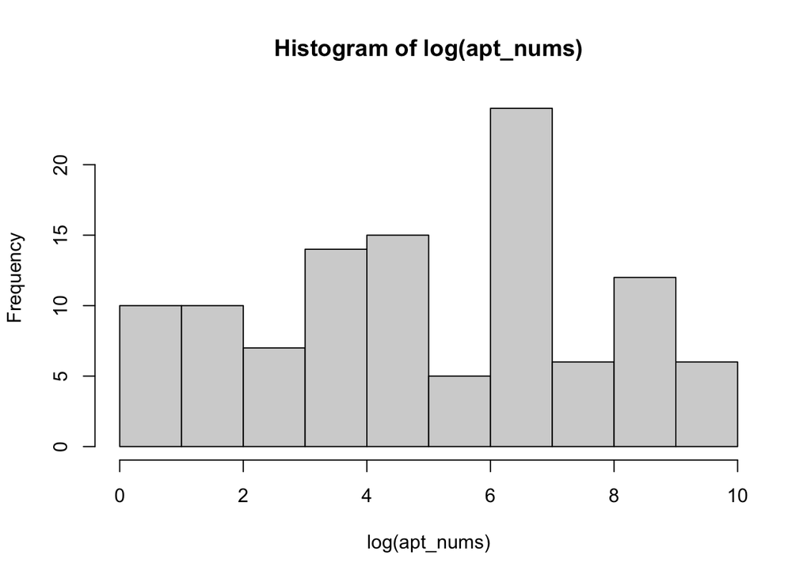

      ::: :::
   5. Benford’s law is an observation about the distribution of the leading digit of real numerical data. Examine whether the apartment numbers appear to follow Benford’s law. Do you think the apartment numbers would pass as real data?

      ::: {.cell}

      ```r
      first_digits <- as.numeric(substr(apt_nums, 1, 1))
      hist(first_digits)
      ```

      ::: {.cell-output-display}

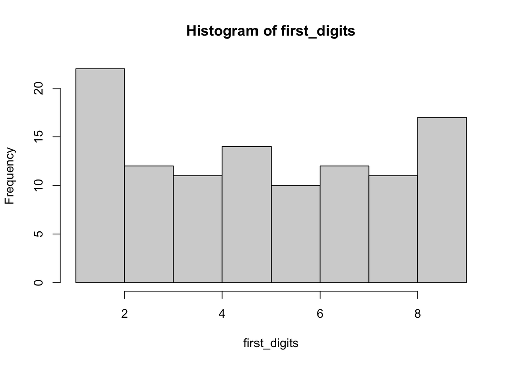

      ::: :::

      This does not appear to follow Benford’s law. The distribution is not logarithmic, and the 9 appears the second most often instead of the least often.
   6. ::: {.cell}

      ```r
      address_delimited <- unlist(strsplit(d$address, " "))
      last_digits <- sub(" .*", "", d$address)
      last_digits <- as.numeric(substring(last_digits, nchar(last_digits)))
      hist(last_digits)
      ```

      ::: {.cell-output-display}

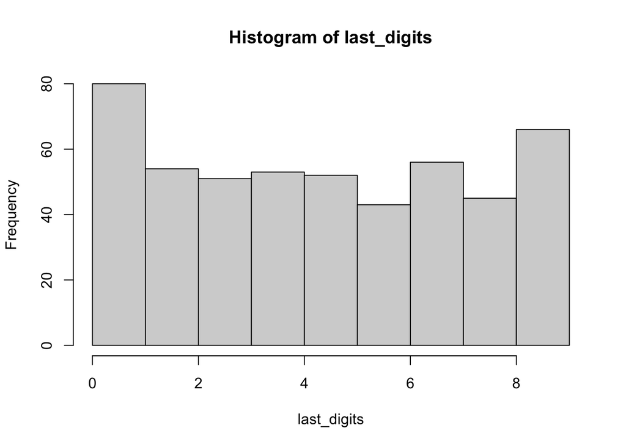

      ::: :::

      This does not appear to follow Benford’s law. The distribution is not logarithmic, and the 9 appears the second most often instead of the least often.